# Chapter3

2. Lets read the alc data.

```r
alc <- read.csv("C:/Users/juhoi/OneDrive/Tiedostot/Coodaushit/IODS-project/create_alc.R")
names(alc)
```

```
##  [1] "X"          "school"     "sex"        "age"        "address"
##  [6] "famsize"    "Pstatus"    "Medu"       "Fedu"       "Mjob"
## [11] "Fjob"       "reason"     "nursery"    "internet"   "guardian"
## [16] "traveltime" "studytime"  "failures"   "schoolsup"  "famsup"
## [21] "paid"       "activities" "higher"     "romantic"   "famrel"
## [26] "freetime"   "goout"      "Dalc"       "Walc"       "health"
## [31] "absences"   "G1"         "G2"         "G3"         "alc_use"
## [36] "high_use"
```

3. I choose sex, final exam scores, famsize and studytime as my variables. My hypotheses are as follows: There’s less females than males who consume a lot of alcohol. I also assume that a person who doesn’t consume a lot of alcohol does get better grades as someone who does drink a lot.

```r
library(tidyr)
library(dplyr)
```

```r
library(ggplot2)
```

4. Now we test the hypothesis.

```r
alc %>% group_by(sex, high_use) %>%summarise(count=n(),mean_grade=mean(G3))
```

```
## # A tibble: 4 x 4
## # Groups:   sex [?]
##   sex   high_use count mean_grade
##   <fct> <lgl>    <int>      <dbl>
## 1 F     FALSE      156       11.4
## 2 F     TRUE        42       11.7
## 3 M     FALSE      112       12.2
## 4 M     TRUE        72       10.3
```

First here is the crosstabulation for alcohol usage, sex and the average of the final exam grades. Results tell us two things: i.) Higher percentage of men than women use alcohol a lot. ii.) For women, those who drink more have slightly higher grades. For men, binge-drinkers have worse grades.

Then we create a boxplot of high alcohol usages effects to the final grades.

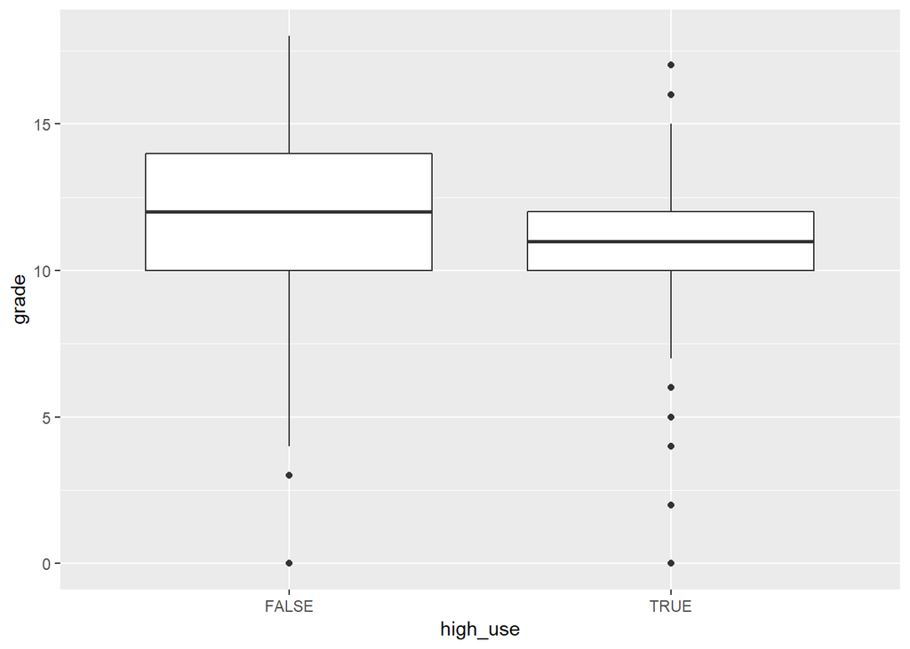

```r
g1 <- ggplot(alc, aes(x= high_use, y=G3), col=sex)
g1 + geom_boxplot()+ylab("grade")
```

It is clear that on average, alcohol-lovers have worse grades than moderate drinkers.

Then here we have alcohol usage vs. study time as a barplot. Low drinkers in black and high drinkers in green.

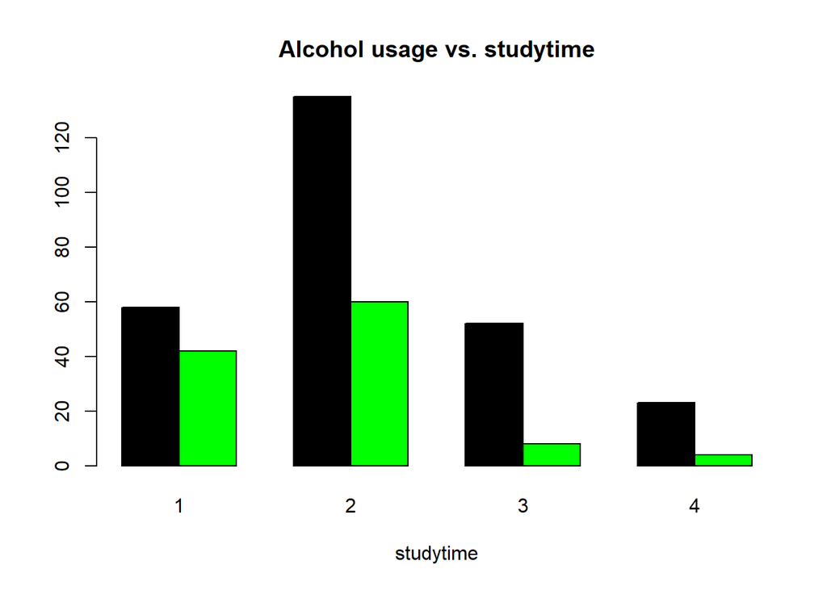

```r
counts <- table(alc$high_use, alc$studytime)
barplot(counts, main= "Alcohol usage vs. studytime", xlab="studytime", beside=TRUE, col = c("black", "green"))
```

Key ratio here is the share of drunkards in each category of study time. The shares are about equally small in 4 and 3 but get bigger in 2 and in 1 it is almost as usual to drink a lot than not to drin a lot.

Then we compare alcohol usage to family size.

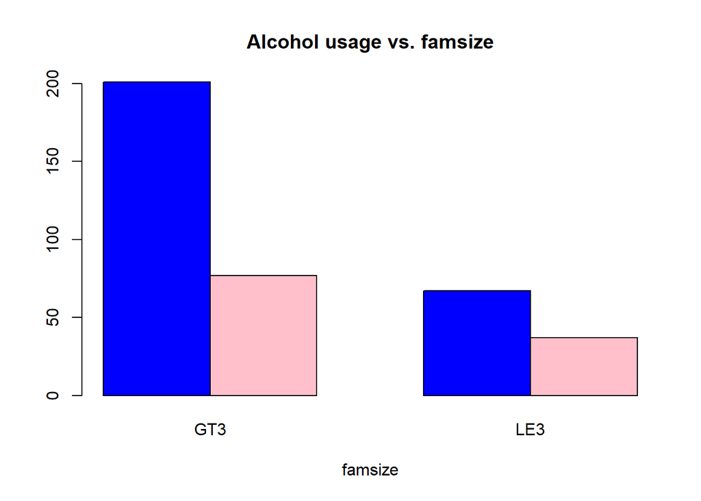

```r
counts2 <- table(alc$high_use, alc$famsize)
barplot(counts2, main= "Alcohol usage vs. famsize", xlab="famsize", beside=TRUE, col = c("blue", "pink"))
```

The result is that slightly higher share of students from small families, than from big families, drink a lot.

5. Logistic regression is here.

```r
m <- glm(high_use ~ famsize + sex + G3 + studytime, data = alc, family = "binomial")
summary(m)
```

```
##
## Call:
## glm(formula = high_use ~ famsize + sex + G3 + studytime, family = "binomial",
##     data = alc)
##
## Deviance Residuals:
##     Min       1Q   Median       3Q      Max
## -1.4556  -0.8448  -0.6728   1.1674   2.1425
##
## Coefficients:
##             Estimate Std. Error z value Pr(>|z|)
## (Intercept)  0.36140    0.50827   0.711  0.47706
## famsizeLE3   0.31601    0.25722   1.229  0.21923
## sexM         0.67284    0.24445   2.752  0.00592 **
## G3          -0.07463    0.03598  -2.074  0.03806 *
## studytime   -0.41808    0.15933  -2.624  0.00869 **
## ---
## Signif. codes:  0 '***' 0.001 '**' 0.01 '*' 0.05 '.' 0.1 ' ' 1
##
## (Dispersion parameter for binomial family taken to be 1)
##
##     Null deviance: 465.68  on 381  degrees of freedom
## Residual deviance: 435.28  on 377  degrees of freedom
## AIC: 445.28
##
## Number of Fisher Scoring iterations: 4
```

Coefficients as odds ratios:

```r
OR <- coef(m) %>% exp
OR
```

```
## (Intercept)  famsizeLE3        sexM          G3   studytime
##   1.4353404   1.3716456   1.9598015   0.9280889   0.6583124
```

COnfidence intervals:

```r
CI <- confint(m) %>% exp
CI
```

```
##                 2.5 %    97.5 %
## (Intercept) 0.5317356 3.9213022
## famsizeLE3  0.8244681 2.2647911
## sexM        1.2165115 3.1774177
## G3          0.8641265 0.9954148
## studytime   0.4773416 0.8930376
```

```r
library(gmodels)
m <- glm(high_use ~ sex + studytime, data = alc, family = "binomial")
probabilities <- predict(m, type = "response")
alc <- mutate(alc, probability = probabilities)
alc <- mutate(alc, prediction = probability > 0.3)
select(alc, studytime, sex, high_use, probability, prediction) %>% tail(10)
```

```
##     studytime sex high_use probability prediction
## 373         1   M    FALSE   0.4795667       TRUE
## 374         1   M     TRUE   0.4795667       TRUE
## 375         3   F    FALSE   0.1536065      FALSE
## 376         1   F    FALSE   0.3222140       TRUE
## 377         3   F    FALSE   0.1536065      FALSE
## 378         2   F    FALSE   0.2270396      FALSE
## 379         2   F    FALSE   0.2270396      FALSE
## 380         2   F    FALSE   0.2270396      FALSE
## 381         1   M     TRUE   0.4795667       TRUE
## 382         1   M     TRUE   0.4795667       TRUE
```

```r
table(high_use = alc$high_use, prediction = alc$prediction)
```

```
##         prediction
## high_use FALSE TRUE
##    FALSE   158  110
##    TRUE     37   77
```

```r
CrossTable(alc$high_use, alc$prediction)
```

```
##
##
##    Cell Contents
## |-------------------------|
## |                       N |
## | Chi-square contribution |
## |           N / Row Total |
## |           N / Col Total |
## |         N / Table Total |
## |-------------------------|
##
##
## Total Observations in Table:  382
##
##
##              | alc$prediction
## alc$high_use |     FALSE |      TRUE | Row Total |
## -------------|-----------|-----------|-----------|
##        FALSE |       158 |       110 |       268 |
##              |     3.283 |     3.424 |           |
##              |     0.590 |     0.410 |     0.702 |
##              |     0.810 |     0.588 |           |
##              |     0.414 |     0.288 |           |
## -------------|-----------|-----------|-----------|
##         TRUE |        37 |        77 |       114 |
##              |     7.719 |     8.049 |           |
##              |     0.325 |     0.675 |     0.298 |
##              |     0.190 |     0.412 |           |
##              |     0.097 |     0.202 |           |
## -------------|-----------|-----------|-----------|
## Column Total |       195 |       187 |       382 |
##              |     0.510 |     0.490 |           |
## -------------|-----------|-----------|-----------|
##
##
```

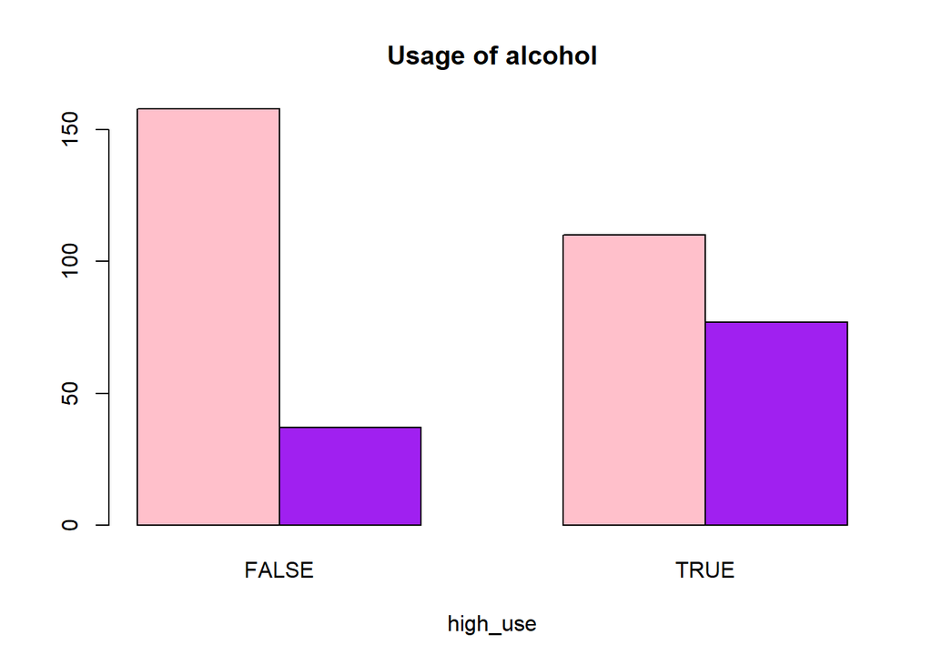

```r
counts3 <- table(alc$high_use, alc$prediction)
barplot(counts3, main = "Usage of alcohol", xlab = "high_use", col = c("pink", "purple"), beside = TRUE)
```

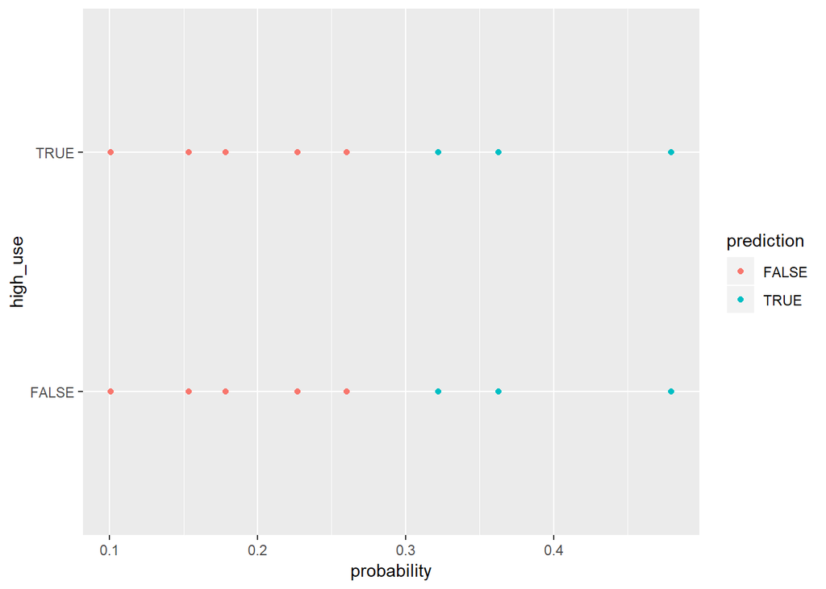

```r
g <- ggplot(alc, aes(x = probability, y = high_use, col = prediction))

g + geom_point()
```

```r
table(high_use = alc$high_use, prediction = alc$prediction) %>% prop.table %>% addmargins
```

```
##         prediction
## high_use      FALSE       TRUE        Sum
##    FALSE 0.41361257 0.28795812 0.70157068
##    TRUE  0.09685864 0.20157068 0.29842932
##    Sum   0.51047120 0.48952880 1.00000000
```

```r
loss_func <- function(class, prob) {
  n_wrong <- abs(class - prob) > 0.5
  mean(n_wrong)
}

loss_func(class = alc$high_use, prob = 0)
```

```
## [1] 0.2984293
```

According to the results, the model provided provides a sense of reality, even if it it statistically not very reliable. By simply guessing what the results would be, the ideas that one comes up with could be similar but more accurate. What the model probably works for though, is that is offers some slight validation for any guesses made. Not much can be concluded from the model alone however, since the ratio of wrong predictions is quite large